# **DATA ANALYSIS DES DONNEES D’ANOREXIES**

###### **auteur: Charly NANA KONGUEP**

###### **date: 22/10/2019**

**Introduction**

L’étude menée porte sur des patients souffrant d’anorexies. L’anorexie, ou “manque d’appétit”, est une pathologie qui fait partie de la famille des troubles du comportement alimentaire (TCA) et qui se manifeste pas une perte de poids intentionnelle.

Afin de tester l’efficacite de deux traitements sur des patients atteints d’anorexies, trois groupes de patients ont été contistué parmis lequel on compte un groupe de patients appelé groupe de controle qui n’a suivi aucun traitement (Placébo) et qui servira de reférence pour les analyses. Parmis les differents traitements utilisés, nous avons la thérapie familiale noté **‘FT’**, la thérapie Cognitive Behavioural Treatment noté **‘CBT’**, et le groupe controle noté **‘Cont’**.

**Les donnees**

Les données soumises à notre étude sont constitués de 3 variables et de 72 individus (patients). Parmis les variables, nous avons une variable qualitative noté **‘trait’** faisant reférence au type de traitement soumis aux patients et constitué de 03 modalités et deux variables quantitatives continues noté **‘pre’** et **‘post’** correspondant respectivement au poids des patients en début et en fin de l’étude.

**Objectifs**

L’objectif général de l’étude est de mesurer l’éfficatité ou l’impact (qui peut etre négatif ou positif) des differents traitements soumis aux patients. Autrement dit, il s’agit d’identifier quel est le meilleur traitement.

**Remarque :** Afin de rendre le notebook R, beaucoup plus agréable à lire et conserver une bonne présentation, certains code R ont été volontairement masqué.

```r
#Importation du data.frame:
ano <- read.table(file = "DonneesAnorexie.txt",header = TRUE)
#Conversion du poids en [kg]:
ano$pre <- ano$pre*0.453
ano$post <- ano$post*0.453
#Extraction des données par types de traitements:
ano_Cont <- ano[which(ano$trait=='Cont'),]
ano_FT <- ano[which(ano$trait=='FT'),]
ano_CBT <- ano[which(ano$trait=='CBT'),]
```

```r
c1 <- c('FT','CBT','Cont')
c2 <- c(nrow(ano_FT),nrow(ano_CBT),nrow(ano_Cont))
c3 <- c(paste(round(mean(ano_FT$pre),1)," kg"),paste(round(mean(ano_CBT$pre),1)," kg"),paste(round(mean(ano_Cont$pre),1)," kg"))
presentation <- data.frame(c1,c2,c3)
names(presentation) <- c('Type de traitement','Nombre de patients','Poids moyen initial')
library(knitr)
```

#### **Distributions des groupes à l’état initial**

Dans le tableau ci-contre sont représentés:

| Type de traitement | Nombre de patients | Poids moyen initial |
| --- | --- | --- |
| FT | 17 | 37.7 kg |
| CBT | 29 | 37.5 kg |
| Cont | 26 | 36.9 kg |

[output not shown]

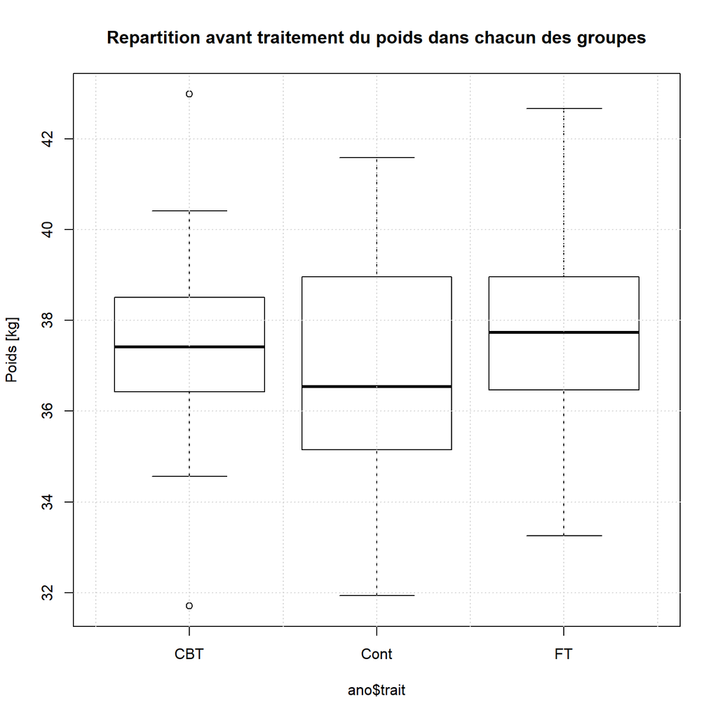

```r
boxplot(ano$pre~ano$trait,main = "Repartition avant traitement du poids dans chacun des groupes",ylab="Poids [kg]")
grid()
```

#### **Choix des variables explicatives**

La comparaison du poids moyen, avant et après traitements ne peut constituer une base d’analyse comparative entre les traitements.  
En effet, il serait impossible de connaître les effets d’un traitement par une étude exclusive à un temps donné (avant ou après).  
Il paraît cependant tout à fait judicieux de mettre en perspective les évolutions des distributions associées à chacun des trois groupes.  
Dans un deuxième temps, nous tâcherons d’illustrer l’accroissement du poids moyen dans chacun des groupes.

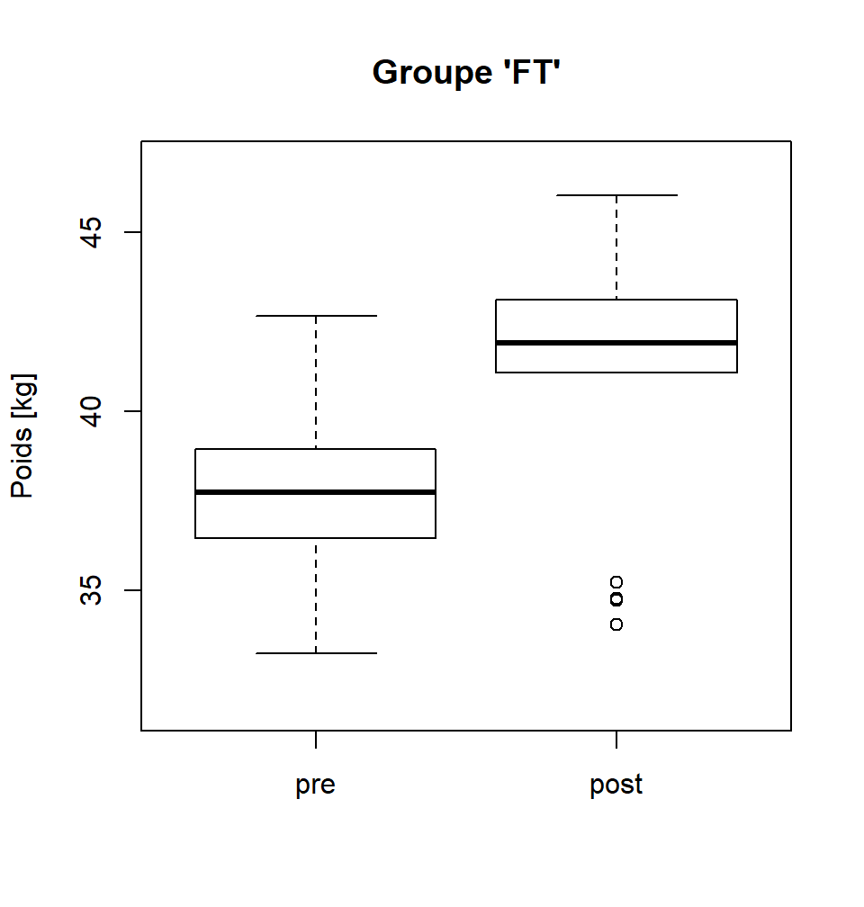

```r
boxplot(ano_FT[,c(2,3)],main="Groupe 'FT'",ylab="Poids [kg]",ylim=c(min(ano[,c(2,3)]),max(ano[,c(2,3)])))
```

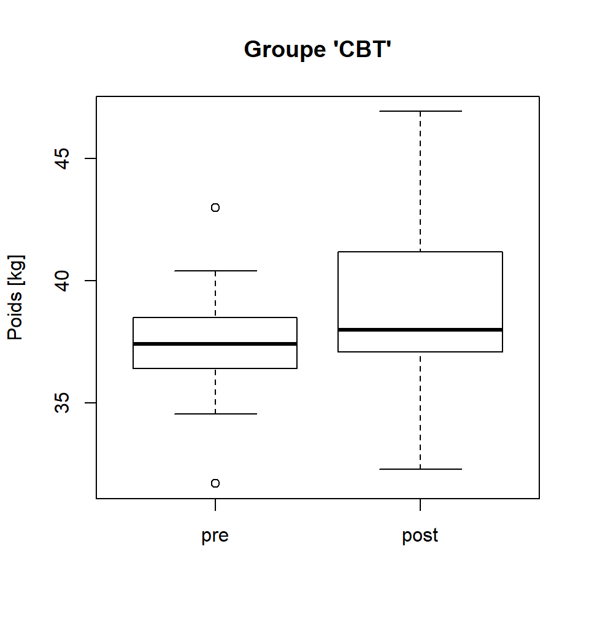

```r
boxplot(ano_CBT[,c(2,3)],main="Groupe 'CBT'",ylab="Poids [kg]",ylim=c(min(ano[,c(2,3)]),max(ano[,c(2,3)])))
```

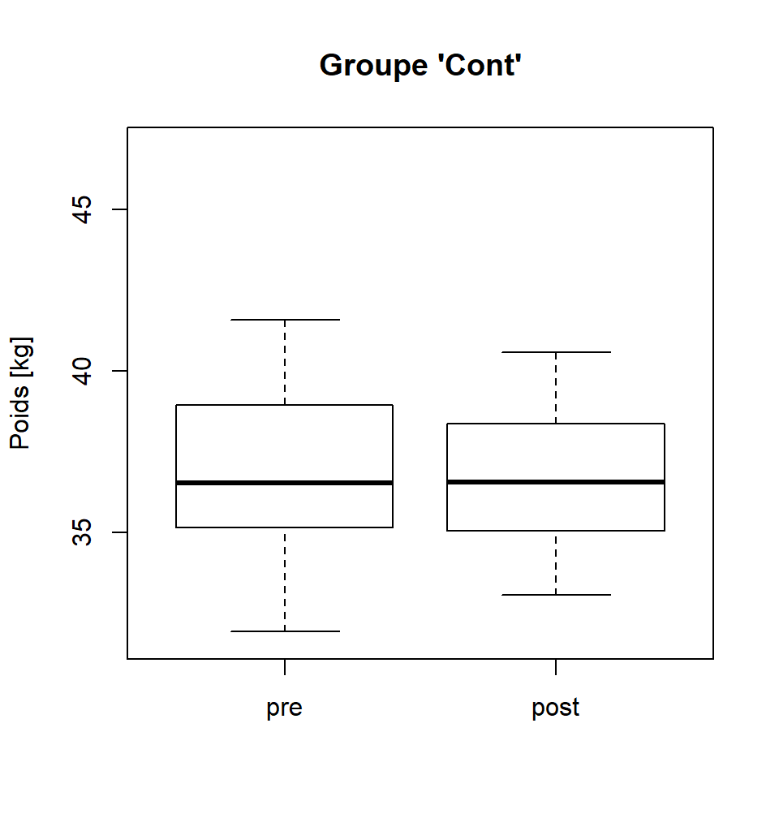

| ‘FT’ en [kg] | Avant | Apres |
| --- | --- | --- |
| Maximum | 42.67 | 46.02 |
| Mediane | 37.73 | 41.90 |
| Minimum | 33.25 | 34.07 |

| ‘CBT’ en [kg] | Avant | Apres |
| --- | --- | --- |
| Maximum | 42.99 | 46.93 |
| Mediane | 37.42 | 38.01 |
| Minimum | 31.71 | 32.30 |

| ‘Cont’ en [kg] | Avant | Apres |
| --- | --- | --- |
| Maximum | 41.59 | 40.59 |
| Mediane | 36.53 | 36.56 |
| Minimum | 31.94 | 33.07 |

```r
boxplot(ano_Cont[,c(2,3)],main="Groupe 'Cont'",ylab="Poids [kg]",ylim=c(min(ano[,c(2,3)]),max(ano[,c(2,3)])))
```

Forte disparité entre la médianne avant et après le traitement : ce qui indique que le traitement ‘FT’ à un effet sur le poids des patients atteints d’anorexies. Cependant, ce résultat reste à être confirmé par un test statistique de Student sur l’échantillon apparié (poids avant - poids après), sous reserve de la normalité des données.

Faible disparité entre la médiane avant et après le traitement : ce qui indique que le traitement ‘CBT’ n’a pas d’effet sur le poids des patients atteints d’anorexies. De plus, on note que les poids après traitement sont un peu plus étendus. Comme précédemment, ce résultat reste à être confirmé par un test statistique.

Concernant le groupe de control soumis au placébo, on observe une très faible disparité entre la médiane avant et après le traitement comme le montre le tableau ci-dessus. De plus, les plages de valeurs avant et après sont à peu près les mêmes. On en déduit que le placébo n’a aucun effet sur le poids des patients : ce qui était prévisible comme résultat

Dans le tableau ci-contre sont représentés:

1. Le *nombre* de patients qui sont en prise de poids à l’issue de l’étude, auquel nous précisons le *nombre total* de patients par groupe,
2. Le pourcentage de *réussite* du traitement, c’est-à-dire le pourcentage des patients prenant du poids par traitements,
3. La *prise (ou perte) moyenne* de poids par groupes.

|  | FT | CBT | Cont |
| --- | --- | --- | --- |
| Patients en prise de poids | 13 / 17 | 18 / 29 | 11 / 26 |
| Pourcentage de reussites | 76.5 % | 62.1 % | 42.3 % |
| Prise/Perte moyen [kg] | 3.29 | 1.36 | -0.2 |

| Il est important de souligner que le groupe de contrôle est en moyenne en perte de poids. Contrairement aux deux autres groupes ‘FT’ et ‘CBT’. |
| --- |
| En effet, comme illustrer dans le graphique ci-contre, nous remarquons que le plus grand accroissement du poids moyen est réalisé par le groupe suivant le traitement ‘FT’ *Family Therapy*. |

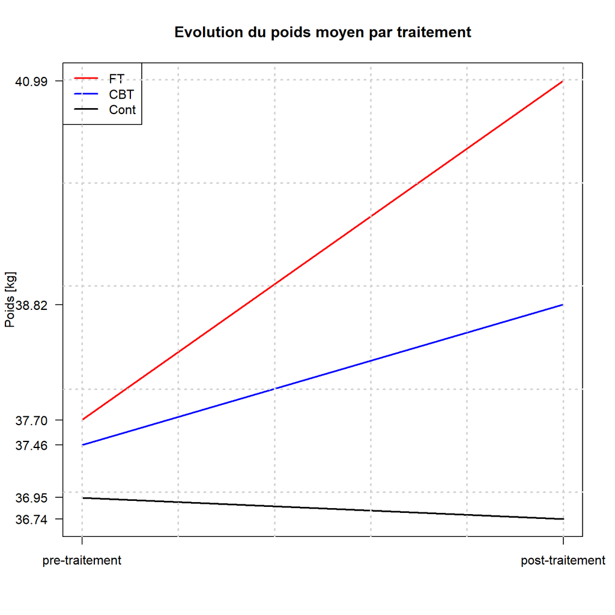

#### **Étude de l’évolution du groupe de contrôle**

Afin de nous permettre d’établir des conclusions relatives à la qualité des traitements ‘FT’ et ‘CBT’, il nous faut justifier le rôle de témoin du groupe de contrôle dans le cadre de cette étude.

| Malgré les variations individuelles au sein du groupe ‘Cont’, les paramètres globaux et plus particulièrement la médiane, restent stable. |
| --- |
| Ce qui satisfait aux caractères requis au le rôle de témoin. |

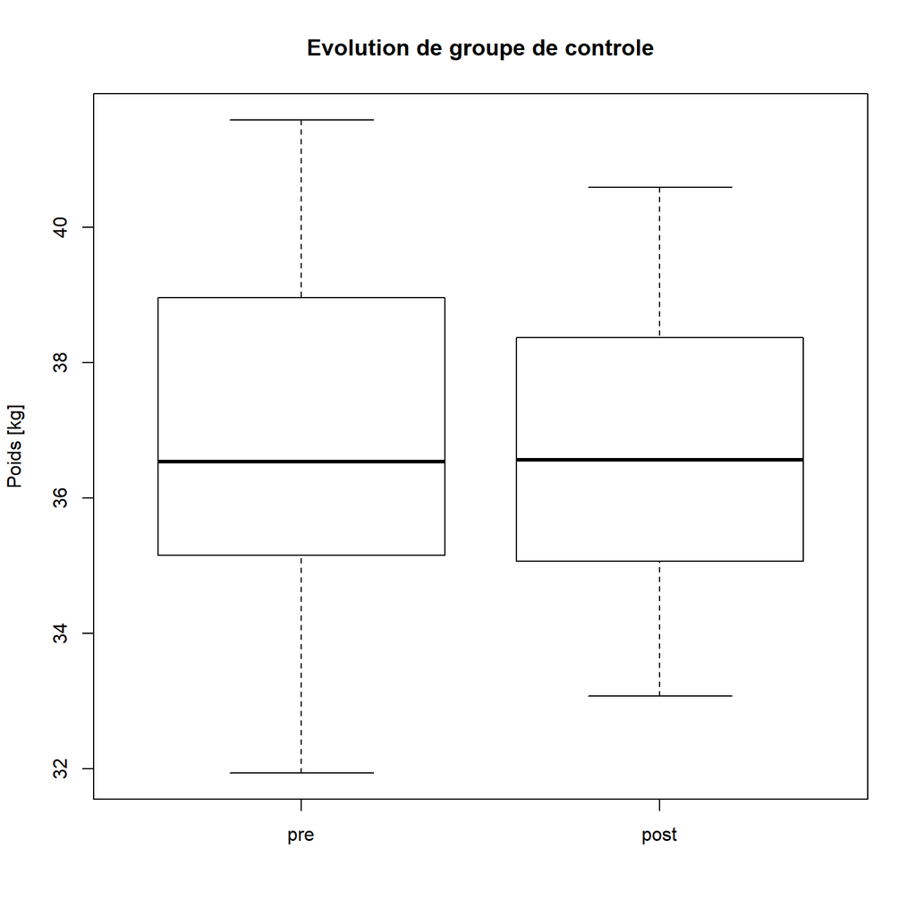

#### **Comparaisons des groupes de traitements ‘FT’ et ‘CBT’**

Comparons à présent les deux traitements ‘FT’ et ‘CBT’ entre eux, et analysons leurs efficacités respectives.  
Dans toute cette partie, nous avons utilisé le *QQ-plot* qui est un outil graphique permettant de comparer des distributions entre elles.  
Nous avons, de plus, rajouté la première bissectrice au sein du graphe afin de mieux juger l’adéquation des distributions.

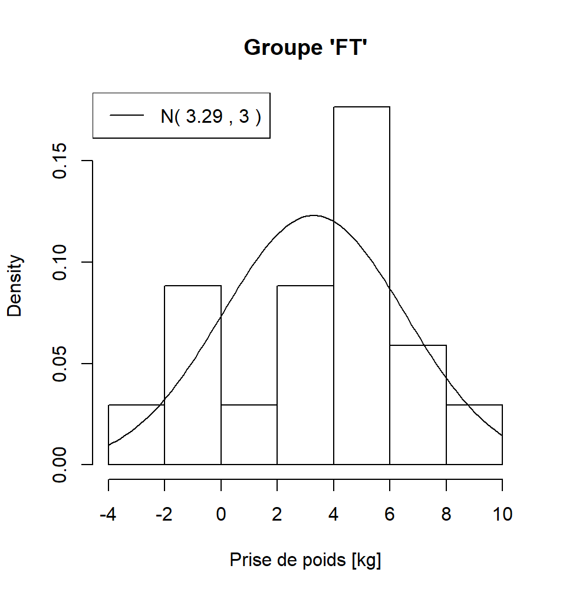

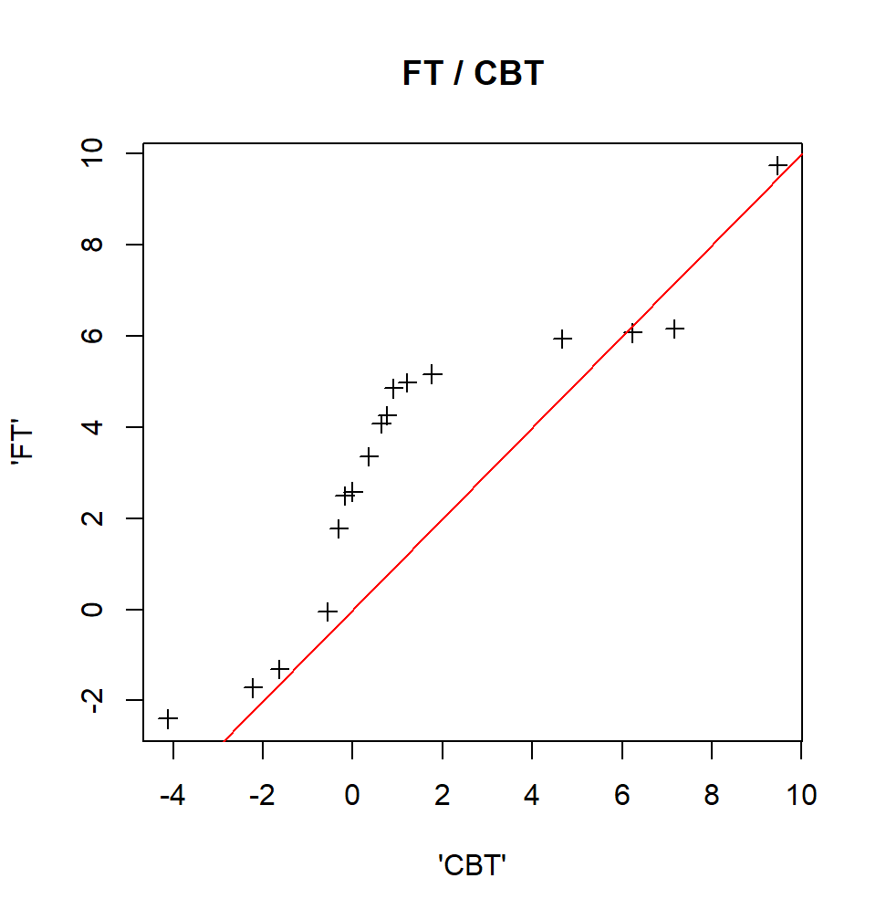

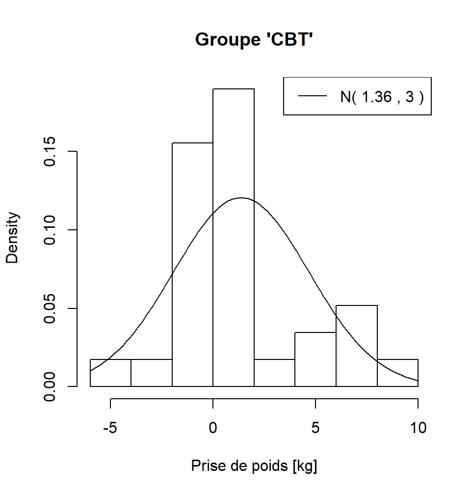

L’adéquation entre l’histogramme et la densité n’est pas bonne.  
La loi de la prise de poids n’est pas centrée autour de sa moyenne comme une loi gaussienne.

Nous voyons que le traitement ‘FT’  
est nettement supérieur au ‘CBT’.  
Nous constatons qu’il est tout particulièrement meilleur pour les valeurs situées autour de la moyenne.

Idemment, l’adéquation n’est pas bonne.  
Le “pic” de l’histogramme est bien trop grand pour une gaussienne.

**Conclusion générale**

Le but de cette étude était de mesurer l’impact des différents traitements sur le poids des patients et comparer les trois méthodes de traitement. Pour ce faire, nous nous sommes appuyés sur des outils statistiques descriptifs et plus particulierement des outils statistiques adaptés à nos données tels que les box-plots, les histogrammes, les QQ-plot, ect…

Les principaux resultats qui en découlent sont :

**Limites et recommendations**

Nous pouvons relever dans cette étude deux principales insuffisances ou limites.

- La première concerne la répartition des patients par groupe. En effet, nous pouvons déplorer le fait que le nombre de patients ai été inégalement répartit par groupe, avec le groupe FT qui est très peu représenté (24% seulement) par rapport aux autres groupes (CBT : 40%, Cont : 36%). Il aurait été souhaitable que la proportion des patients par groupe soit à peu près la même.
- La Deuxième limite concerne la taille de l’échantillon qui semble quelque peu faible : ce qui a pour conséquence de rendre les analyses statistiques peu précises. Il aurait été souhaitable d’avoir une taille d’échantillon plus grande.